# Happiness Score Analysis

Elie Ghazzoul

2024-06-03

This report analyzes the happiness scores of countries using various factors such as GDP, Gini index, and family. The analysis includes data extraction, cleaning, visualization, and modeling using linear regression and Lasso regression.

# Data Extraction and cleaning

## Load data

```r
file_path <- "C:/Users/User/Downloads/2017.csv"
data <- read.csv(file_path)
View(data)
```

## Extract Gini Index from wikipedia

```r
url <- "https://en.wikipedia.org/wiki/List_of_countries_by_income_equality"
webpage <- read_html(url)
# Inspect the structure of the webpage to identify the correct table
tables <- webpage %>% html_nodes("table")
length(tables)
```

```
## [1] 8
```

```r
# Extract the table we are interested in
table <- tables[[2]] %>% html_table(fill = TRUE)
head(table)
```

```
## # A tibble: 6 × 9
##   Country   Subregion       Region   `UN R/P` `UN R/P` `CIA R/P[4]` `CIA R/P[4]`
##   <chr>     <chr>           <chr>    <chr>    <chr>    <chr>        <chr>
## 1 Country   Subregion       Region   "10%[4]" 20%[7]   "10%"        "Year"
## 2 Albania   Southern Europe Europe   "7.2"    4.2      "7.2"        "2004"
## 3 Algeria   Northern Africa Africa   "9.6"    4.0      "9.6"        "1995"
## 4 Angola    Middle Africa   Africa   ""       9.0      ""           ""
## 5 Argentina South America   Americas "31.6"   8.8      "35.0"       "2007"
## 6 Armenia   Western Asia    Asia     "8.0"    5.0      "25.8"       "2004"
## # ℹ 2 more variables: `World Bank Gini[5][6]` <chr>,
## #   `World Bank Gini[5][6]` <chr>
```

```r
colnames(table)
```

```
## [1] "Country"               "Subregion"             "Region"
## [4] "UN R/P"                "UN R/P"                "CIA R/P[4]"
## [7] "CIA R/P[4]"            "World Bank Gini[5][6]" "World Bank Gini[5][6]"
```

```r
colnames(table) <- make.unique(colnames(table))
colnames(table)
```

```
## [1] "Country"                 "Subregion"
## [3] "Region"                  "UN R/P"
## [5] "UN R/P.1"                "CIA R/P[4]"
## [7] "CIA R/P[4].1"            "World Bank Gini[5][6]"
## [9] "World Bank Gini[5][6].1"
```

```r
gini_data <- table %>%
  select( `Country`,  `World Bank Gini[5][6]`)
```

## Merged Data

```r
existing_data <- read.csv(file_path)
merged_data <- merge(existing_data, gini_data, by.x = "Country", by.y = "Country", all.x = TRUE)
View(merged_data)
```

## Missing Values in the Merged data

```r
# Convert Gini index to numeric and handle any coercion issues
merged_data$`World Bank Gini[5][6]` <- as.numeric(merged_data$`World Bank Gini[5][6]`)
cat("Missing values in Gini index: ", sum(is.na(merged_data$`World Bank Gini[5][6]`)), "\n")
```

```
## Missing values in Gini index:  11
```

```r
# Identify countries with missing Gini index values
countries_with_na_gini <- merged_data %>%
  filter(is.na(`World Bank Gini[5][6]`)) %>%
  select(Country)
print(countries_with_na_gini)
```

```
##                     Country
## 1               Afghanistan
## 2                   Bahrain
## 3       Congo (Brazzaville)
## 4          Congo (Kinshasa)
## 5   Hong Kong S.A.R., China
## 6                    Kuwait
## 7                     Libya
## 8                 Macedonia
## 9              North Cyprus
## 10  Palestinian Territories
## 11 Taiwan Province of China
```

```r
# Fill in missing Gini index values manually instead of the mean of gini index
merged_data <- merged_data %>%
  mutate(`World Bank Gini[5][6]` = case_when(
    Country == "Afghanistan" ~ 41,
    Country == "Bahrain" ~ 44.3,
    Country == "Congo (Brazzaville)" ~ 48.9,
    Country == "Congo (Kinshasa)" ~ 42,
    Country == "Hong Kong S.A.R., China" ~ 49.9,
    Country == "Kuwait" ~ 47.1,
    Country == "Libya" ~ 44.1,
    Country == "Macedonia" ~ 68.2,
    Country == "North Cyprus" ~ 68.5,
    Country == "Palestinian Territories" ~ 33.7,
    Country == "Taiwan Province of China" ~ 34.2,
    TRUE ~ `World Bank Gini[5][6]`
  ))
View(merged_data)
str(merged_data)
```

```
## 'data.frame':    155 obs. of  13 variables:
##  $ Country                      : chr  "Afghanistan" "Albania" "Algeria" "Angola" ...
##  $ Happiness.Rank               : int  141 109 53 140 24 121 10 13 85 41 ...
##  $ Happiness.Score              : num  3.79 4.64 5.87 3.8 6.6 ...
##  $ Whisker.high                 : num  3.87 4.75 5.98 3.95 6.69 ...
##  $ Whisker.low                  : num  3.71 4.54 5.77 3.64 6.51 ...
##  $ Economy..GDP.per.Capita.     : num  0.401 0.996 1.092 0.858 1.185 ...
##  $ Family                       : num  0.582 0.804 1.146 1.104 1.44 ...
##  $ Health..Life.Expectancy.     : num  0.1807 0.7312 0.6176 0.0499 0.6951 ...
##  $ Freedom                      : num  0.106 0.381 0.233 0 0.495 ...
##  $ Generosity                   : num  0.3119 0.2013 0.0694 0.0979 0.1095 ...
##  $ Trust..Government.Corruption.: num  0.0612 0.0399 0.1461 0.0697 0.0597 ...
##  $ Dystopia.Residual            : num  2.15 1.49 2.57 1.61 2.61 ...
##  $ World Bank Gini[5][6]        : num  41 29.4 27.6 51.3 40.7 27.9 34.3 30.7 26.6 44.3 ...
```

# Data Visualization

## Scatter Plot of Happiness Score vs GDP

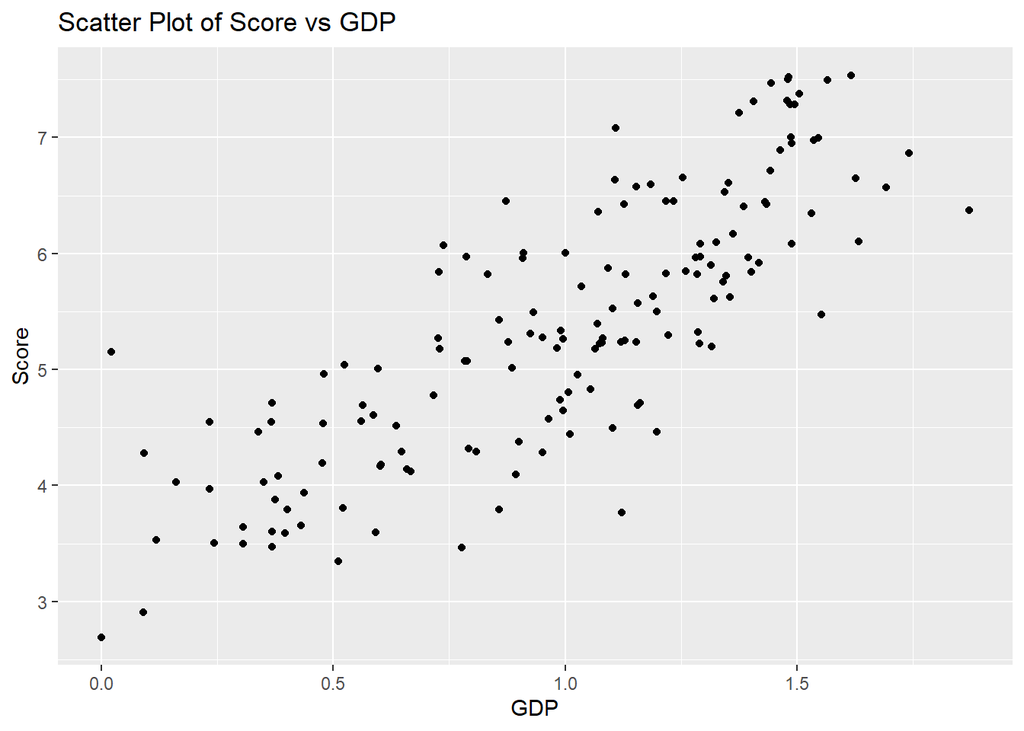

```r
ggplot(merged_data, aes(x = Economy..GDP.per.Capita., y = Happiness.Score)) +
  geom_point() +
  labs(title = "Scatter Plot of Score vs GDP", x = "GDP", y = "Score")
```

In this scatter plot above, We can see clearly a positive relationship between the GDP and the score. When GDP increases, the Score gets higher meaning we can see a positive linear relationship. This is not a surprise for us, because when you have a good GDP in your country eventually people will be happier and more stressed-free and this is visualized in this scatter plot.

## Correlation Heatmap

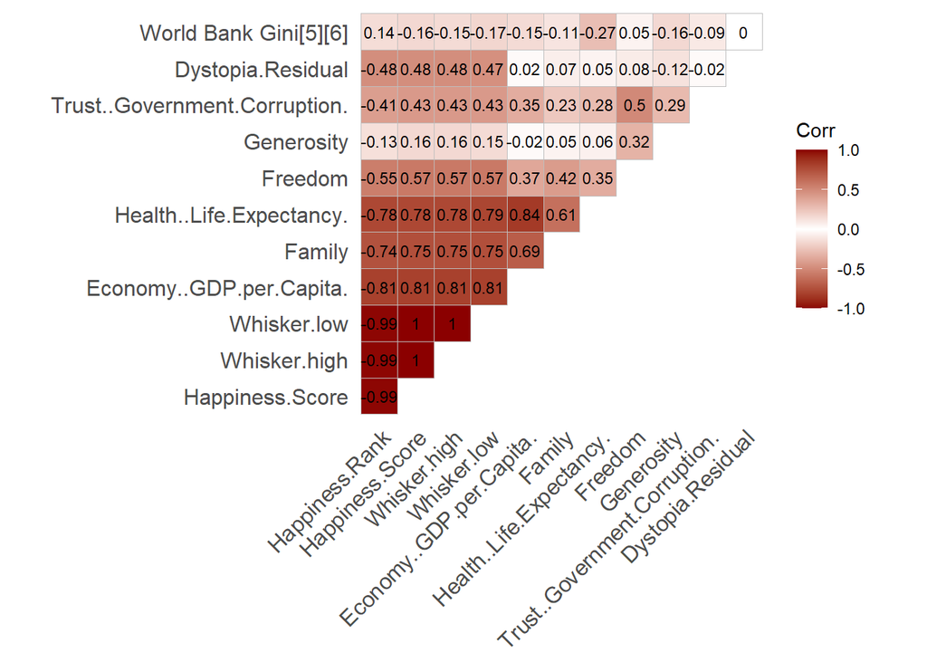

```r
numeric_data <- merged_data[, sapply(merged_data, is.numeric)]
correlation_matrix <- cor(numeric_data)
ggcorrplot(
  correlation_matrix,
  type = "upper",
  colors = c("darkred", "white", "darkred"),
  lab = TRUE,
  lab_size = 3,
  show.diag = FALSE
) +
  theme(
    panel.grid = element_blank(),
    panel.border = element_blank()
  )
```

For our correlation heat map, we’re trying to understand our variables and they interact with each other. As we can see,the most correlated variables with the happiness score are: GDP, health,family (as social support) and also we can consider freedom (>0.5). For the rest of the variables they don’t really affect our Y variable because the coefficient is less than 0.5.

# Model training and evaluation

## Rename the variables

```r
merged_data <- merged_data %>%
  rename(
    gdp = Economy..GDP.per.Capita.,
    gini_index = `World Bank Gini[5][6]`,
    family = Family,
    happiness_score = Happiness.Score
  )
```

We renamed our variables because it will be easier to read and understand the execution of the models below.

## Split data intro train and valid

```r
set.seed(100)
split = sample(1:2, nrow(merged_data), replace = TRUE, prob = c(0.8, 0.2))
train = merged_data[split == 1, ]
val = merged_data[split == 2, ]
```

Dividing data into training and validation sets helps ensure that a machine learning model learns patterns effectively while preventing overfitting. The training set is used to train the model, while the validation set is used for unbiased evaluation and model selection, leading to better generalization to new, unseen data.

## Accuracy function

```r
acc_error <- function(actual, pred) {
  mape <- mean(abs((actual - pred)/actual)) * 100
  mae <- mean(abs(actual - pred))
  RMSE <- sqrt(mean((actual - pred)^2))
  vec <- c(mape, mae, RMSE)
  names(vec) <- c("MAPE", "MAE", "RMSE")
  return(vec)
}
# to be familiar with our train and valid scores
summary(train$happiness_score)
```

```
##    Min. 1st Qu.  Median    Mean 3rd Qu.    Max.
##   2.693   4.545   5.279   5.387   6.344   7.537
```

```r
summary(val$happiness_score)
```

```
##    Min. 1st Qu.  Median    Mean 3rd Qu.    Max.
##   3.471   4.287   5.312   5.218   5.838   7.284
```

The acc_error function calculates three common error metrics—Mean Absolute Percentage Error (MAPE), Mean Absolute Error (MAE), and Root Mean Squared Error (RMSE)—to assess the accuracy of predictions against actual values. These metrics provide insights into the model’s performance, helping to understand the magnitude and impact of prediction errors. For my analysis, I will focus on the RMSE for comparing model and on the Adjusted R squared to detect overfitting

# Model 1:linear regression

As requested we used only the variables defined: GDP, Gini Index and Family.

```r
model1 <- lm(happiness_score ~ gdp + gini_index + family, data = train)
summary(model1)
```

```
##
## Call:
## lm(formula = happiness_score ~ gdp + gini_index + family, data = train)
##
## Residuals:
##      Min       1Q   Median       3Q      Max
## -1.73503 -0.34804 -0.04168  0.39223  1.90606
##
## Coefficients:
##              Estimate Std. Error t value Pr(>|t|)
## (Intercept)  2.357216   0.343030   6.872 2.95e-10 ***
## gdp          1.468293   0.181030   8.111 4.70e-13 ***
## gini_index  -0.005407   0.006374  -0.848    0.398
## family       1.460777   0.262604   5.563 1.62e-07 ***
## ---
## Signif. codes:  0 '***' 0.001 '**' 0.01 '*' 0.05 '.' 0.1 ' ' 1
##
## Residual standard error: 0.6109 on 121 degrees of freedom
## Multiple R-squared:  0.7152, Adjusted R-squared:  0.7082
## F-statistic: 101.3 on 3 and 121 DF,  p-value: < 2.2e-16
```

```r
train_predictions1 <- predict(model1, newdata = train)
train_perform1 <- acc_error(train$happiness_score, train_predictions1)
train_perform1
```

```
##      MAPE       MAE      RMSE
## 9.1725968 0.4722310 0.6010893
```

```r
val_predictions1 <- predict(model1, newdata = val)
perform1 <- acc_error(val$happiness_score, val_predictions1)
perform1
```

```
##      MAPE       MAE      RMSE
## 7.8089359 0.3999483 0.5023825
```

# Model 2: Linear regression with all the variables

In order to determine which variables are relevant: I made a model with all the variables to get familiar.

```r
model2 <- lm(happiness_score ~ gdp + Health..Life.Expectancy. + Freedom + Generosity + Trust..Government.Corruption. + Dystopia.Residual + gini_index + family, data = train)
summary(model2)
```

```
##
## Call:
## lm(formula = happiness_score ~ gdp + Health..Life.Expectancy. +
##     Freedom + Generosity + Trust..Government.Corruption. + Dystopia.Residual +
##     gini_index + family, data = train)
##
## Residuals:
##        Min         1Q     Median         3Q        Max
## -5.775e-04 -2.128e-04 -2.751e-05  2.651e-04  4.758e-04
##
## Coefficients:
##                                Estimate Std. Error   t value Pr(>|t|)
## (Intercept)                   7.716e-05  2.042e-04     0.378    0.706
## gdp                           1.000e+00  1.359e-04  7361.408   <2e-16 ***
## Health..Life.Expectancy.      9.998e-01  2.179e-04  4588.358   <2e-16 ***
## Freedom                       9.999e-01  2.280e-04  4385.653   <2e-16 ***
## Generosity                    1.000e+00  2.157e-04  4637.718   <2e-16 ***
## Trust..Government.Corruption. 9.997e-01  3.308e-04  3022.026   <2e-16 ***
## Dystopia.Residual             1.000e+00  5.322e-05 18789.342   <2e-16 ***
## gini_index                    1.702e-06  3.236e-06     0.526    0.600
## family                        9.999e-01  1.312e-04  7621.183   <2e-16 ***
## ---
## Signif. codes:  0 '***' 0.001 '**' 0.01 '*' 0.05 '.' 0.1 ' ' 1
##
## Residual standard error: 0.0002933 on 116 degrees of freedom
## Multiple R-squared:      1,  Adjusted R-squared:      1
## F-statistic: 2.305e+08 on 8 and 116 DF,  p-value: < 2.2e-16
```

```r
train_predictions2 <- predict(model2, newdata = train)
train_perform2 <- acc_error(train$happiness_score, train_predictions2)
train_perform2
```

```
##         MAPE          MAE         RMSE
## 0.0047573034 0.0002427380 0.0002825236
```

```r
val_predictions2 <- predict(model2, newdata = val)
perform2 <- acc_error(val$happiness_score, val_predictions2)
perform2
```

```
##         MAPE          MAE         RMSE
## 0.0046698349 0.0002254197 0.0002664727
```

# Model 3: With the correlated variables

```r
model3 <- lm(happiness_score ~ gdp + Health..Life.Expectancy. + Freedom + family, data = train)
summary(model3)
```

```
##
## Call:
## lm(formula = happiness_score ~ gdp + Health..Life.Expectancy. +
##     Freedom + family, data = train)
##
## Residuals:
##      Min       1Q   Median       3Q      Max
## -1.66862 -0.24432 -0.03928  0.31977  1.20797
##
## Coefficients:
##                          Estimate Std. Error t value Pr(>|t|)
## (Intercept)                1.7880     0.2079   8.602 3.54e-14 ***
## gdp                        0.7915     0.2227   3.554 0.000543 ***
## Health..Life.Expectancy.   1.2457     0.3681   3.384 0.000965 ***
## Freedom                    2.0413     0.3420   5.968 2.50e-08 ***
## family                     1.0654     0.2294   4.643 8.84e-06 ***
## ---
## Signif. codes:  0 '***' 0.001 '**' 0.01 '*' 0.05 '.' 0.1 ' ' 1
##
## Residual standard error: 0.5174 on 120 degrees of freedom
## Multiple R-squared:  0.7974, Adjusted R-squared:  0.7907
## F-statistic: 118.1 on 4 and 120 DF,  p-value: < 2.2e-16
```

```r
train_predictions3 <- predict(model3, newdata = train)
train_perform3 <- acc_error(train$happiness_score, train_predictions3)
train_perform3
```

```
##      MAPE       MAE      RMSE
## 7.4977801 0.3854451 0.5069923
```

```r
val_predictions3 <- predict(model3, newdata = val)
perform3 <- acc_error(val$happiness_score, val_predictions3)
perform3
```

```
##      MAPE       MAE      RMSE
## 7.5243006 0.3666977 0.4582873
```

# Model 4: model 3 + gini index

```r
model4 <- lm(happiness_score ~ gdp +Health..Life.Expectancy. +Freedom
               +gini_index+ family, data = train)
summary(model4)
```

```
##
## Call:
## lm(formula = happiness_score ~ gdp + Health..Life.Expectancy. +
##     Freedom + gini_index + family, data = train)
##
## Residuals:
##      Min       1Q   Median       3Q      Max
## -1.62672 -0.22517 -0.04068  0.32400  1.19115
##
## Coefficients:
##                           Estimate Std. Error t value Pr(>|t|)
## (Intercept)               1.932420   0.300172   6.438 2.67e-09 ***
## gdp                       0.809902   0.224911   3.601 0.000464 ***
## Health..Life.Expectancy.  1.184595   0.380106   3.116 0.002295 **
## Freedom                   2.062255   0.344247   5.991 2.28e-08 ***
## gini_index               -0.003735   0.005590  -0.668 0.505301
## family                    1.067433   0.229992   4.641 8.98e-06 ***
## ---
## Signif. codes:  0 '***' 0.001 '**' 0.01 '*' 0.05 '.' 0.1 ' ' 1
##
## Residual standard error: 0.5186 on 119 degrees of freedom
## Multiple R-squared:  0.7982, Adjusted R-squared:  0.7897
## F-statistic: 94.12 on 5 and 119 DF,  p-value: < 2.2e-16
```

```r
train_predictions4 <- predict(model4, newdata = train)
train_perform4=acc_error(train$happiness_score, train_predictions4)
train_perform4
```

```
##      MAPE       MAE      RMSE
## 7.4934228 0.3842338 0.5060438
```

```r
val_predictions4 <- predict(model4, newdata = val)
perform4=acc_error(val$happiness_score, val_predictions4)
perform4
```

```
##      MAPE       MAE      RMSE
## 7.4937063 0.3655981 0.4577640
```

In order to determine which model is the most appropriate from the models executed above, we need to consider the following criteria: RMSE —> lower values indicate better performance. Adj R squared —> values tending to 1 indicate overfitting.

```r
summary_table1 <- data.frame(
  Model = c("Linear Model 1", "Linear Model 2", "Linear Model 3", "Linear Model 4"),
  Num_Variables = c(3, 8, 4, 5),
  Train_RMSE = c(0.6010893, 0.0002825236, 0.5069923, 0.5060438),
  Val_RMSE = c(0.5023825 , 0.0002664727 , 0.4582873, 0.4577640 ),
  Adj_R_Squared = c(0.7082, 1.00, 0.7907, 0.7897 )
)
print(summary_table1)
```

```
##            Model Num_Variables   Train_RMSE     Val_RMSE Adj_R_Squared
## 1 Linear Model 1             3 0.6010893000 0.5023825000        0.7082
## 2 Linear Model 2             8 0.0002825236 0.0002664727        1.0000
## 3 Linear Model 3             4 0.5069923000 0.4582873000        0.7907
## 4 Linear Model 4             5 0.5060438000 0.4577640000        0.7897
```

Model 3: Offers a good balance of predictors without the inclusion of potentially irrelevant variables (gini_index), showing good validation performance. Model 4: Similar to Model 3 but includes gini_index. Performance metrics are very close to those of Model 3, slightly better on validation set.

Model 3 is recommended as it strikes a balance between simplicity (fewer predictors) and performance, showing robust validation results without evidence of overfitting.

# Lasso Regression

Lasso regression, or Least Absolute Shrinkage and Selection Operator, is a type of linear regression that performs both variable selection and regularization to enhance the prediction accuracy and interpretability of the statistical model it produces. The key feature of Lasso regression is that it can shrink some of the coefficients to zero, effectively selecting a simpler model that retains only the most impactful variables.

Lambda (λ) is the tuning parameter in Lasso regression that controls the strength of the penalty applied to the coefficients. A higher value of lambda results in more regularization, shrinking coefficients more aggressively, whereas a lower value applies less regularization.

Choosing the optimal lambda is crucial for achieving the best predictive performance. This is typically done using cross-validation, a technique that involves dividing the data into multiple subsets, training the model on some subsets, and validating it on the remaining subsets. By evaluating the model’s performance across different values of lambda, we can select the lambda that minimizes the cross-validation error. The use of cross-validation for selecting the optimal lambda ensures that the model is robust and less sensitive to variations in the training data. This leads to more reliable and stable predictions.

# LASSO Model 1 : GDP,Gini and Family

We used the same variables as presented in the model 1 above

```r
y <- train$happiness_score
x1 <- as.matrix(train[, c("gdp", "gini_index", "family")])
lambda_grid <- 10^seq(-3, 1, length = 100)
#Help to identify the optimal value of lambda that minimizes the cross-validation error:
cv_fit1 <- cv.glmnet(x1, y, alpha = 1, lambda = lambda_grid, nfolds = 5)
calculate_rmse <- function(actual, predicted) {
  sqrt(mean((actual - predicted)^2))
}
rmse_values1 <- numeric(length(cv_fit1$lambda))
for (i in 1:length(cv_fit1$lambda)) {
  lasso_model1 <- glmnet(x1, y, alpha = 1, lambda = cv_fit1$lambda[i])
  predictions1 <- predict(lasso_model1, x1)
  rmse_values1[i] <- calculate_rmse(y, predictions1)
}
results1 <- data.frame(lambda = cv_fit1$lambda, RMSE = rmse_values1)
print(results1)
```

```
##           lambda      RMSE
## 1   10.000000000 1.1263962
## 2    9.111627561 1.1263962
## 3    8.302175681 1.1263962
## 4    7.564633276 1.1263962
## 5    6.892612104 1.1263962
## 6    6.280291442 1.1263962
## 7    5.722367659 1.1263962
## 8    5.214008288 1.1263962
## 9    4.750810162 1.1263962
## 10   4.328761281 1.1263962
## 11   3.944206059 1.1263962
## 12   3.593813664 1.1263962
## 13   3.274549163 1.1263962
## 14   2.983647240 1.1263962
```

[output cut: 86 more lines]

```r
#gives the lambda value that resulted in the lowest cross-validation error:
lambda_best <- cv_fit1$lambda.min
lambda_best
```

```
## [1] 0.01353048
```

```r
#Create a data frame with alpha and lambda, which will be used by the train function for model training:
tuning_grid1 <- expand.grid(alpha = 1, lambda = lambda_best)
#Evaluating the model's performance and ensuring that it is not overfitting.
train_control <- trainControl(method = "cv", number = 5)
cv_model1 <- train(happiness_score ~ gdp + gini_index + family,
                   data = train,
                   method = "glmnet",
                   trControl = train_control,
                   tuneGrid = tuning_grid1)
print(cv_model1)
```

```
## glmnet
##
## 125 samples
##   3 predictor
##
## No pre-processing
## Resampling: Cross-Validated (5 fold)
## Summary of sample sizes: 100, 100, 100, 100, 100
## Resampling results:
##
##   RMSE       Rsquared   MAE
##   0.6213275  0.7232963  0.4918459
##
## Tuning parameter 'alpha' was held constant at a value of 1
## Tuning
##  parameter 'lambda' was held constant at a value of 0.01353048
```

```r
#The final model
lasso_model1 <- cv_model1$finalModel
#These coefficients indicate the impact of each x1 on the happiness score:
coef(lasso_model1)
```

```
## 4 x 58 sparse Matrix of class "dgCMatrix"
```

```
##   [[ suppressing 58 column names 's0', 's1', 's2' ... ]]
```

[output not shown]

# LASSO Model 2 : GDP , freedom ,Gini index, Family and health life expectancy

```r
y <- train$happiness_score
x2 <- as.matrix(train[,c("gdp","family","Freedom","gini_index","Health..Life.Expectancy.")])

lambda_grid <- 10^seq(-3, 1, length = 100)
cv_fit2 <- cv.glmnet(x2, y, alpha = 1, lambda = lambda_grid, nfolds = 5)
calculate_rmse <- function(actual, predicted) {
  sqrt(mean((actual - predicted)^2))
}
rmse_values2 <- numeric(length(cv_fit2$lambda))
for (i in 1:length(cv_fit2$lambda)) {
  lasso_model2 <- glmnet(x2, y, alpha = 1, lambda = cv_fit2$lambda[i])
  predictions2 <- predict(lasso_model2, x2)
  rmse_values2[i] <- calculate_rmse(y, predictions2)
}
results2 <- data.frame(lambda = cv_fit2$lambda, RMSE = rmse_values2)
print(results2)
```

```
##           lambda      RMSE
## 1   10.000000000 1.1263962
## 2    9.111627561 1.1263962
## 3    8.302175681 1.1263962
## 4    7.564633276 1.1263962
## 5    6.892612104 1.1263962
## 6    6.280291442 1.1263962
## 7    5.722367659 1.1263962
## 8    5.214008288 1.1263962
## 9    4.750810162 1.1263962
## 10   4.328761281 1.1263962
## 11   3.944206059 1.1263962
## 12   3.593813664 1.1263962
## 13   3.274549163 1.1263962
## 14   2.983647240 1.1263962
```

[output cut: 86 more lines]

```r
lambda_bestt <- cv_fit2$lambda.min
lambda_bestt
```

```
## [1] 0.007742637
```

```r
tuning_grid2 <- expand.grid(alpha = 1, lambda = lambda_bestt)
train_control <- trainControl(method = "cv", number = 5)
cv_model2 <- train(happiness_score ~ gdp +Health..Life.Expectancy.+  family+Freedom+gini_index,
                   data = train,
                   method = "glmnet",
                   trControl = train_control,
                   tuneGrid = tuning_grid2)
print(cv_model2)
```

```
## glmnet
##
## 125 samples
##   5 predictor
##
## No pre-processing
## Resampling: Cross-Validated (5 fold)
## Summary of sample sizes: 100, 100, 100, 100, 100
## Resampling results:
##
##   RMSE       Rsquared   MAE
##   0.5186693  0.7960031  0.3970135
##
## Tuning parameter 'alpha' was held constant at a value of 1
## Tuning
##  parameter 'lambda' was held constant at a value of 0.007742637
```

```r
lasso_model2 <- cv_model2$finalModel

coef(lasso_model2)
```

```
## 6 x 59 sparse Matrix of class "dgCMatrix"
```

```
##   [[ suppressing 59 column names 's0', 's1', 's2' ... ]]
```

[output not shown]

[output cut: 36 more lines]

```
## gini_index               -0.002436157 -0.002551582 -0.002656753 -0.002752581
##
## (Intercept)               1.933989092  1.933785622  1.933651083  1.933537488
## gdp                       0.802292216  0.802971036  0.803542414  0.804089382
## Health..Life.Expectancy.  1.185930059  1.185955152  1.185888982  1.185792241
## family                    1.056722734  1.057659625  1.058545942  1.059343821
## Freedom                   2.024524104  2.027799858  2.030862518  2.033653557
## gini_index               -0.002839896 -0.002918662 -0.002991082 -0.003057172
##
## (Intercept)               1.933436847  1.933346069  1.933263647  1.933188639
## gdp                       0.804599611  0.805068669  0.805497418  0.805888513
## Health..Life.Expectancy.  1.185691748  1.185596195  1.185507865  1.185426984
## family                    1.060065442  1.060720965  1.061317590  1.061860998
## Freedom                   2.036195297  2.038510646  2.040620099  2.042542086
## gini_index               -0.003117417 -0.003172318 -0.003222344 -0.003267926
```

As the coefficient of gini index is slightly equal to 0, we redo our analysis and remove the gini index variable.